# Project 2: Public Health & Epidemiology

#### Question 19H [1 point]

By now, it should be clear that there is a **monthly seasonality** to deaths that has nothing to do with what year it is, even though 2020 was a pandemic year. In fact, that seasonality is so strong that it ends up as a very strong predictor - about as strong as the spatial autocorrelation! Although I wish I could dive into that with you deeply now, I would not be able to do the topic justice. Note that Merrimack offers an entire course on time series - but if you are unable to take the course but want to learn more on your own, one resource I can recommend is [A Little Book of R For Time Series by Avril Coghlan](https://app.readthedocs.org/projects/a-little-book-of-r-for-time-series/downloads/pdf/latest/).

Since you can’t go deeply into doing it, instead you will do a little reading/research. I suggest reading about *temporal autocorrelation* or *seasonal momentum* and how adding time-series lags can help. How might time series lags capture what the “Month” variable alone may not fully capture, in a similar way to how “County” alone may not fully capture spatial relationships?

**Note**: Doing the time-aware data partition into before 2020 and after 2020 IS a form of controlling for temporal patterns/seasonality, albeit not as robust as including temporally lagged variables.

> Time-series lagged variables could help because they allow the model to use information from previous time periods rather than relying only on the current month label. The Month variable captures seasonality by indicating where we are in the calendar year, but it does not directly account for what happened in the months leading up to the current observation.

> This is similar to the role of spatial lag variables. County identifies a location, but it does not capture the influence of neighboring counties. Likewise, Month identifies a point in time, but it does not capture the influence of previous months. A time-series lag variable, such as mortality from the previous month, can help capture temporal autocorrelation, where observations that are closer together in time tend to be more similar than observations farther apart.

> For example, if mortality has been increasing steadily over several months, a lagged mortality variable would allow the model to recognize that momentum and use it when making predictions. As a result, time-series lags can capture temporal relationships that the Month variable alone may miss and may improve predictive performance..

#### Question 19I [1 point]

Now, let’s say you add several time-series lagged variables to your random forest; but with 10-fold CV, the testing MAE is 0.129. The scale of the target variable is unchanged - recall that previously, you got a testing MAE of 0.745. Does this suggest that the time series lagged variables are helping or hurting the model? If I tell you that the training MAE is 0.134, do you think the model is **overfitted**, **underfitted**, or doing pretty well?

> The time-series lagged variables appear to be helping the model substantially. The testing MAE decreased from 0.745 to 0.129, which represents a large reduction in prediction error while the scale of the target variable remained unchanged. This suggests that the lagged variables are providing useful information that improves the model’s ability to predict mortality.

> The training MAE (0.134) is also very close to the testing MAE (0.129). Because the model performs similarly on both the training and testing data, there is little evidence of overfitting. At the same time, the relatively low error values suggest that the model is not underfitting. Instead, the model appears to be generalizing well to unseen data.

> Overall, these results suggest that adding time-series lagged variables improved model performance and helped the random forest better capture the temporal patterns present in the mortality data.

**Would you like to see how I got this?** This source code contains all of the steps of analysis, with comments, and will show you these same results! Make sure to open the source code if you want to see the step-by-step instructions and not just the output! In brief, what I do is engineer temporal lag and rolling means features to inform the model how the target behaved in the past. Lags are explicitly accounting for temporal autocorrelation; rolling averages show recent trends and smooth noise. Then, I do the time-aware split again using the 2020 data as my holdout testing set. I then add the lagged and rolling means features, along with the spatial lag, month, and year variables as predictors to the RF model and assess performance on the testing holdout set. Note that RF is a particularly good choice for temporal models because it is non-linear; further, adding lags makes it partially time-aware. **However, don’t forget to ALWAYS validate with time held out, not random sampling, in temporal models!**

```r
source("mortalityTemporalLagRF.R")
```

```
## [1] "These are the results of a temporally lagged 10-CV random forest."
## [1] "These are the training performance metrics:"
##   mtry      RMSE  Rsquared       MAE     RMSESD RsquaredSD      MAESD
## 1    2 0.4007984 0.8390208 0.2079359 0.07423216 0.04946869 0.02574079
## 2    5 0.3169941 0.8995420 0.1604059 0.06268867 0.03466540 0.02123300
## 3    8 0.2658770 0.9294839 0.1347351 0.04866931 0.02381615 0.01769750
## [1] "These are the testing performance metrics using the 2020 holdout set:"
## [1] "Random Forest Test RMSE:   0.2455"
## [1] "Random Forest Test MAE:    0.1281"
```

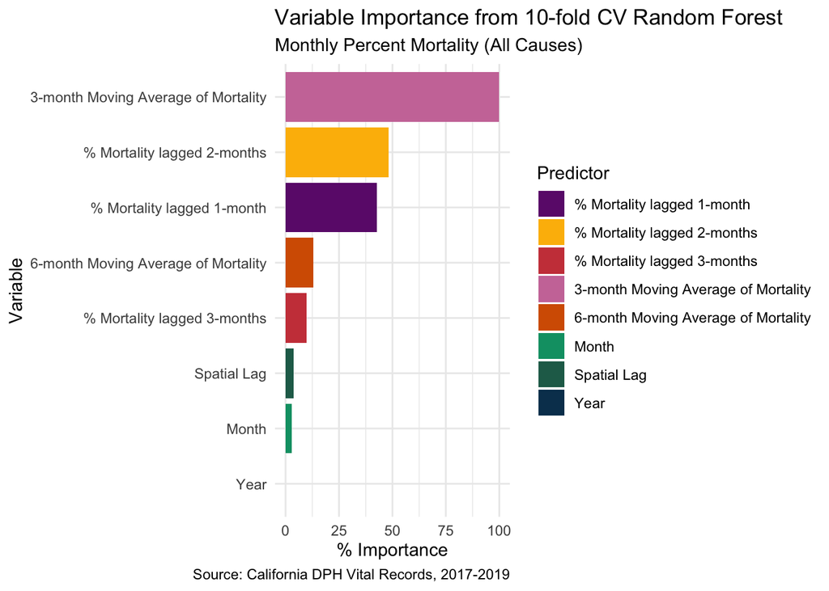

#### Question 19J [1 point]

What is something **else** you can do to improve your model that you have not discussed or explored at all here? **Hint**: Random forest models need complexity!

> One additional way we could improve the model would be to incorporate more relevant predictors beyond the temporal and spatial variables used here. Random forests generally perform best when they have access to a rich set of features that capture different aspects of the underlying process. For example, we could include demographic variables such as age distribution, population density, race and ethnicity, or socioeconomic indicators. We could also include health-related variables such as rates of chronic disease or healthcare access. Because mortality is influenced by many factors beyond time and location, adding these predictors could help the model capture additional variation and improve predictive performance. In particular, the COVID-19 pandemic highlighted how external factors can dramatically affect mortality patterns, suggesting that richer contextual data could further strengthen the model.

#### Question 19K [3 points]

Take all of the findings and interpretations from questions 18A-J and write up a short paragraph or two summary for your stakeholders. Your writing should not be overly technical but it should include caveats and limitations. Make sure to include 1-2 sentences of recommendations about what you would do next.

> Using mortality data from 2017–2019, we developed several predictive models to estimate monthly percent mortality across California counties and evaluated their performance using 2020 data as a holdout testing set. Our analysis found clear evidence of both spatial and temporal patterns in mortality. The spatial lag regression outperformed the ordinary least squares model, indicating that mortality rates in neighboring counties are related and should be considered when making predictions. We also found that month of the year was a strong predictor, suggesting that mortality follows a seasonal pattern that is relatively consistent over time.

> Although the improved model performed much better, several limitations remain. Mortality is influenced by many factors that were not included in our analysis, such as demographic characteristics, socioeconomic conditions, healthcare access, and disease outbreaks. In addition, the unusual conditions of the COVID-19 pandemic highlight the challenge of using historical data to predict outcomes during periods of major disruption.

> Based on these findings, we recommend incorporating additional demographic, health, and environmental predictors into future models. We also recommend continuing to develop time-aware approaches that include temporal lag features, as these provided the largest improvement in predictive performance and appear to capture important trends that simpler models were unable to detect.

# 5 Zooming in on Mortality Causes

California was one of the strictest states when it came to shutdown measures during the COVID-19 pandemic, with both statewide enforcement and a duration longer than some other states in the country. California declared a state of emergency on **March 4, 2020** with a a mandatory statewide stay-at-home order issued on **March 19, 2020**. This statewide order didn’t end until **January 25, 2021**, but it still wouldn’t be until April 6, 2021 when the state announced plans to fully reopen the economy by **June 15, 2021**.

Your stakeholder is actually not as interested in deaths from COVID-19, but actually more interested in how the mandatory stay-at-home order seems to affecting mortality due to certain conditions. **For example, are people less likely to die from accident or injury since they’re under stay-at-home orders?**

## 5.1 Death from Accident & Injury

Because of the mandatory COVID-19 shutdown in California, which has led to generally reduced movement throughout California, your stakeholder would like to know if the number of accidental deaths declined enough **during COVID-19 shutdown** to generate a signal.

**HYPOTHESIS**: You hypothesize that because of intense, mandatory stay-at-home measures, deaths attributed to accidents and injuries (`INJ`) declined during the COVID-19 shutdown during the months of 2020 in California.

You will start, as with all good analysis plans, with some more **Exploratory Data Analysis**.

### 5.1.1 Sex-specific Effects on `INJ` Mortality

#### 5.1.1.1 Total Deaths by Sex

Your stakeholder asks you to be sure to **stratify by the sex of the decedent**, because they suspect there is a difference in death rates by the decedent’s biological sex.

The leading causes of death are located in the `sexDeaths` table because that was how the data were provided to you. They are separated by sex, thus you can check to see if there are sex differences that could matter for your analysis. You need to join some of your tables and calculate some additional metrics as well, including:

- Proportion of deaths from accident or injury out of all deaths (no longer adjusting for population size)
- Ratio of adult females to males in the population
- Ratio of females to males in the population among those over 65 years of age
- Ratio of all adults over the age of 65 (retirement age) to those under retirement age

You have opted to adjust per total deaths, rather than population size, so that you can better examine the fraction of deaths due to particular causes regardless of the underlying size of the population. However, you need to account for the ratio of females to males in the population, as it might be useful now or in future analyses to have access to the ratio of females to males. Similarly, having the ratio of retirees in the population (those over the age of 65 year) relative to non-retirees in the population may also be useful in future analyses. Further, the size of a county may still matter; so you will likely want to retain the total sample size of the county as a control variable as well. Note that, in a more detailed analysis, **population density** would be better than population size, but this is the proxy of county size you currently have to work with!

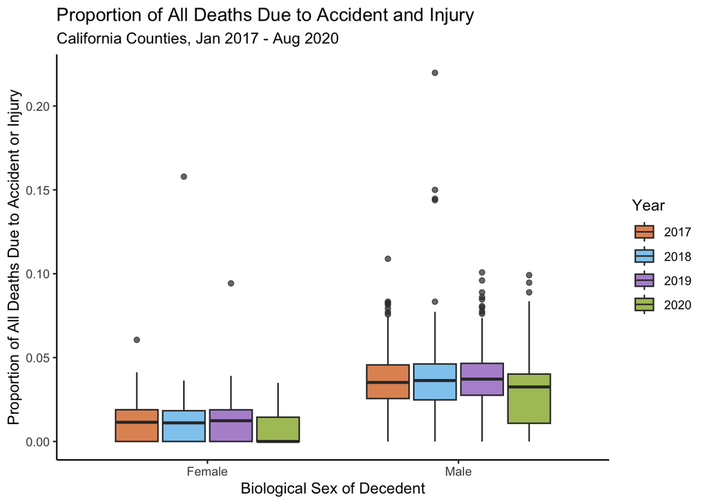

```r
## Join the sex deaths table with the census data; then filter for INJ
injDeaths <- sexDeaths %>%
  full_join(census, by = "County") %>%
  ## Here is where you filter for a specific cause of death relative to sex
  filter(leadingCauseDeath == "INJ") %>%
  ## Now full join with the first 4 columns of the totalDeaths table to get
  ## total deaths also
  full_join(totalDeaths[ , 1:4], by = c("County", "Year", "Month")) %>%
  ## Rename the sexDeaths column to something more appropriate
  rename(injuryDeaths = sexDeaths) %>%
  ## Calculate the proportion of all deaths that are from injury
  ## RELATIVE TO ALL DEATHS (not population!!)
  mutate(deathsInjuriesProportion = injuryDeaths/totalDeaths,
         ## The ratio of females to males in the population
         femaleMaleRatio = femalesN/malesN,
         ## The ratio of 65+ females to males in the population
         femaleMaleRatio65 = females65plus/males65plus,
         ## Ratio of retirees to non-retirees
         retireeRatio = over65/totalN,
         ## Convert the date to a date format for plotting
         Date = as.Date(paste(Year, Month, "1", sep = "-"),
                        format = "%Y-%m-%d")) %>%
         ## Illegal div by 0 turned to NaN; turn back to 0
  mutate(deathsInjuriesProportion = ifelse(deathsInjuriesProportion == "NaN",
                                           0, deathsInjuriesProportion))
```

#### Question 20A [0.5 points]:

Would it be fair to model the proportion of deaths due to injury or accident without accounting for an effect of sex? Why or why not?

> No, it would not be fair to model the proportion of deaths due to injury or accident without accounting for sex. From the boxplot, we can see a clear difference between males and females across all years. Males consistently have a much higher proportion of deaths attributed to accidents and injuries, while females have lower proportions and less variability overall.

> We also see that this pattern remains relatively consistent from 2017 through 2020, suggesting that biological sex is an important factor associated with injury-related mortality. If we ignored sex in the analysis, we could potentially mask meaningful differences between groups and introduce bias into our results. Therefore, sex should either be included as a predictor in the model or used as a stratification variable when examining injury-related mortality.

#### 5.1.1.2 Proportion of Deaths by Sex

What if you calculate the proportion of deaths, for each sex, instead? Wouldn’t that give you a more accurate portrait of any sex-level differences that might exist?

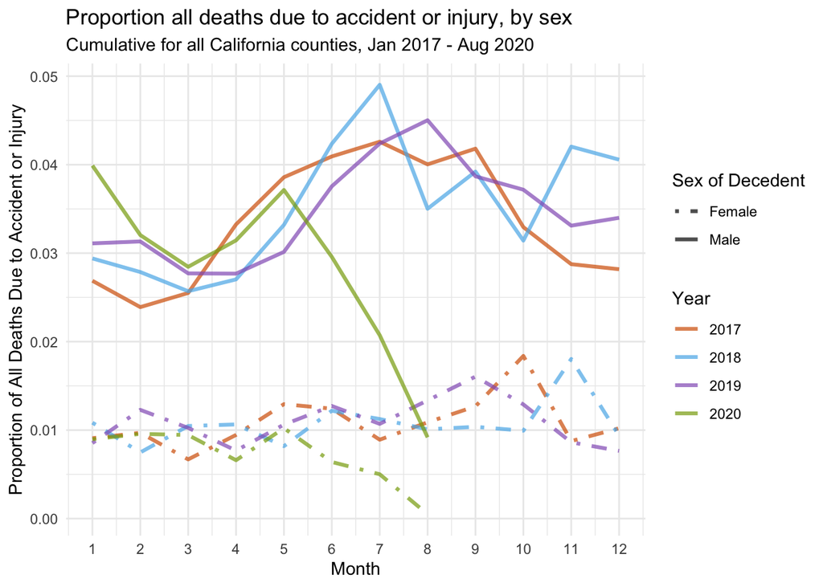

#### Question 20B [0.5 points]:

What do you notice about the trend? Is there anything compelling here? Can you find any possible explanation for what happened in May (month 5) of 2020?

> The solid lines (males) are noticeably higher than the dashed lines (females) across all years, which supports what we observed in Question 20A. Accident- and injury-related deaths appear to account for a larger share of total deaths among males than females. What is most compelling, however, is the 2020 pattern. While the previous years generally show an increase in injury-related deaths during the spring and summer months, the 2020 line declines sharply after May. By August, the proportion of deaths due to accidents and injuries is substantially lower than in previous years. For May 2020 specifically, one possible explanation is the COVID-19 stay-at-home order that had been in place since March 2020. Reduced travel, commuting, and social activity may have lowered opportunities for certain types of accidental injuries, particularly motor vehicle accidents. There may also have been changes in healthcare-seeking behavior, reporting practices, or the overall distribution of causes of death during the pandemic. While this plot alone cannot establish causation, the sharp decline in injury-related mortality during 2020 is consistent with the hypothesis that stay-at-home measures may have reduced deaths from accidents and injuries.

### 5.1.2 Mapping injury-related deaths by stay-at-home orders & sex

So, hopefully you’ve noticed what I’ve noticed about the relationship between the stay-at-home orders and the proportion of overall deaths due to accident or injury, as well as the effect of the shutdown in terms of both decedent biological sexes. You know from your earlier graph that females have a lower proportion of overall death due to accident or injury; next, it would be nice to see what the relationship is spatiotemporally (before and after shutdown) on average accident / injury mortality overall, as well as for each of the sexes separately. This will allow you to see if there is a geographic pattern, as one might expect in denser areas with more roadways, with the effect or not.

Let’s add a label to the dataset to identify whether a month was under stay-at-home orders or not, and call the new feature `stayAtHome`. Notice that I could have coded it as a dummy variable (0 or 1) where 1 is the stay-at-home order condition, but instead I chose to encode it as a category. I can also change the encoding later, if needed. Note also that although I chose to use `Date` as the condition for my `ifelse()`, you could just as easily have chosen a joint conditional using both`Month` and `Year` columns!

```r
## Encode stayAtHome as any date after March 19, 2020
injDeaths <- injDeaths %>%
  mutate(stayAtHome = ifelse(Date >= "2020-03-19", "Stay-at-Home", "None"))
```

Next, let’s calculate a summarized dataframe that groups by `stayAtHome`, `Year`, and `County`, then summarizes an average `deathsInjuriesProportion` for use with the maps. Notice that rather than storing the summarized dataframe, I simply piped it through to join it with the geometry from the shapefile for map-making this time. I was feeling a bit lazy.

```r
##### Calculate the proportion of all deaths due to injury
injuryDeathSummary <- injDeaths %>%
  ## Group by stay-at-home order, year, county, AND sex
  group_by(stayAtHome, Year, County, biologicalSex) %>%
  ## Change the name to make the join easier
  rename(COUNTY_NAM = County) %>%
  ## Mean proportion of deaths for each month-year-county-sex combo
  summarise(deathsInjuriesPercent = mean(deathsInjuriesProportion, na.rm = TRUE)*100) %>%
  ## Join to get the geometries for mapping
  full_join(cali_sf, by = "COUNTY_NAM", relationship = "many-to-many") %>%
  ## Coerce to make sure it is seen as a shapefile
  st_as_sf() %>%
  ungroup()

#### Find the five number summary
summ <- fivenum(injuryDeathSummary$deathsInjuriesPercent)
paste0("The five-number summary of % of deaths that are accident/injury-related is: ")
```

```
## [1] "The five-number summary of % of deaths that are accident/injury-related is: "
```

```r
paste(c("Min", "Lower Quartile", "Median", "Upper Quartile", "Max"),
      round(summ, 3))
```

```
## [1] "Min 0"                "Lower Quartile 0"     "Median 0"
## [4] "Upper Quartile 3.306" "Max 18.489"
```

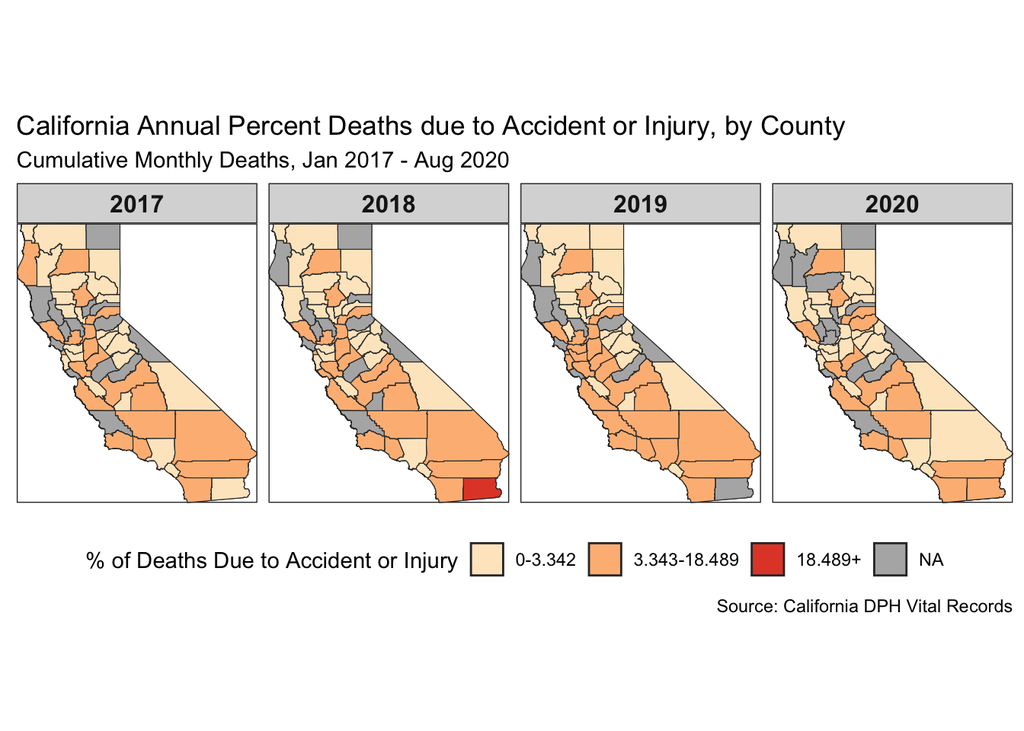

```r
## Notice that, with the minimum, 1st quartile, AND median all equal to 0, we
## really only have three groups

##### Now add on the cuts injuryDeathSummary labels for mapping:
injuryDeathSummary <- injuryDeathSummary %>%
  mutate(deathLabels = cut(deathsInjuriesPercent,
                          breaks = c(0, 3.343, 18.489, Inf),
                          labels = c("0-3.342", "3.343-18.489", "18.489+"),
                          ordered_result = TRUE, right = F))
```

#### Question 21A [0.5 points]::

Do you think there is any evidence that the percent of deaths due to accident & injury changed as a result of the stay-at-home orders? What would provide stronger evidence of a change in percent of deaths due to accident and injury as a result of the shutdown? Do these maps include any evidence of interaction with the sex of the decedent?

**Hint**: Make sure to explain what you would want to do to these maps, either in terms of filtering and/or additional faceting, to better address whether (1) the shutdown has had a likely effect and (2) whether there is an interaction with biological sex on the proportion of deaths due to accident or injury.

> Based on these maps alone, there is not strong evidence that the stay-at-home orders changed the percentage of deaths due to accidents and injuries. While there appear to be some differences between years, the overall spatial patterns look fairly similar from 2017 through 2020, and it is difficult to determine whether any changes are due to the shutdown or simply normal variation over time. To provide stronger evidence, we would want to directly compare counties before and after the stay-at-home order rather than looking at annual summaries. For example, we could facet the maps by the stayAtHome variable or create separate maps for the pre-shutdown and post-shutdown periods. This would allow us to better isolate the potential effect of the shutdown on injury-related mortality. These maps also do not provide evidence about interactions with the sex of the decedent because males and females are combined together. To evaluate whether the shutdown affected males and females differently, we would need to create separate maps or additional facets by biological sex and then compare the spatial patterns between groups.

#### Question 21B [0.5 points]::

Why are some counties filled gray? Are the data truly missing or is it a data maturity problem? Or, is there another reason? (**Hint**: What will happen if the number of deaths in a county are very small?)

> The gray counties are not necessarily missing because the data were unavailable. Instead, many of these counties likely had very small numbers of injury-related deaths. When counts are very small, the data are often suppressed to protect privacy and prevent identification of individuals. As a result, some values become unavailable during the calculation of injury-related mortality proportions and appear as gray on the map. This is more of a data suppression issue than a true missing-data problem. Small rural counties tend to be affected most because they have fewer deaths overall, making it more likely that counts will fall below reporting thresholds.

#### Question 21C [3 points]::

Answer one of the two situations you answered in Question 21A. Either make more compelling maps before and after the shutdown OR show interactivity with biological sex, your choice.

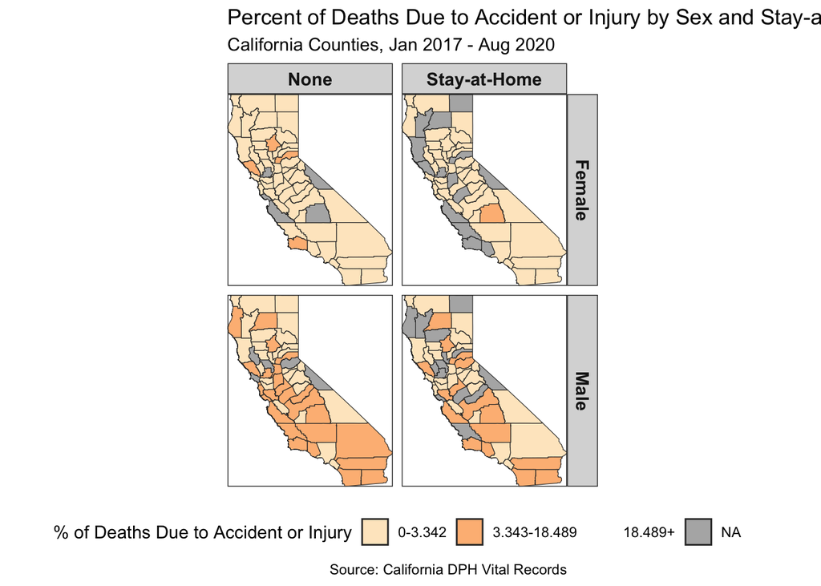

```r
## Create maps stratified by stay-at-home status and biological sex
## This helps us see whether the spatial pattern of injury-related deaths
## differs before vs. during stay-at-home orders for males and females.

injurySexMap <- injDeaths %>%
  group_by(stayAtHome, County, biologicalSex) %>%
  summarise(
    deathsInjuriesPercent = mean(deathsInjuriesProportion, na.rm = TRUE) * 100,
    .groups = "drop"
  ) %>%
  rename(COUNTY_NAM = County) %>%
  full_join(cali_sf, by = "COUNTY_NAM", relationship = "many-to-many") %>%
  st_as_sf()

## Use the same breaks as before for consistency
injurySexMap <- injurySexMap %>%
  mutate(
    deathLabels = cut(
      deathsInjuriesPercent,
      breaks = c(0, 3.343, 18.489, Inf),
      labels = c("0-3.342", "3.343-18.489", "18.489+"),
      ordered_result = TRUE,
      right = FALSE
    )
  )

## Map injury-related deaths by sex and stay-at-home status
ggplot(injurySexMap) +
  geom_sf(aes(fill = deathLabels), color = "gray20", size = 0.2) +
  scale_fill_manual(
    name = "% of Deaths Due to Accident or Injury",
    values = c4a(palette = "brewer.or_rd", n = 3),
    na.value = "gray70",
    drop = FALSE
  ) +
  coord_sf(expand = FALSE) +
  facet_grid(biologicalSex ~ stayAtHome) +
  theme_bw() +
  theme(
    panel.grid = element_blank(),
    panel.background = element_rect(fill = "white"),
    plot.background = element_rect(fill = "white"),
    axis.text = element_blank(),
    axis.ticks = element_blank(),
    axis.title = element_blank(),
    strip.text = element_text(size = 11, face = "bold"),
    legend.position = "bottom"
  ) +
  labs(
    title = "Percent of Deaths Due to Accident or Injury by Sex and Stay-at-Home Status",
    subtitle = "California Counties, Jan 2017 - Aug 2020",
    caption = "Source: California DPH Vital Records"
  )
```

### 5.1.3 Controlling for population-level differences in sex ratio

Even if you didn’t explore biological sex on the map, it seems that there are likely some sex-specific effects in percent of deaths due to accident and injury. But what if some counties have a **skewed sex ratio**? You might need to adjust for that! Although you might expect, *a priori*, for all counties to have a female to male ratio of 1:1, in reality that isn’t always the case.

In order to determine if you need to control for any underlying population-level differences in the sex ratio of each county, you make a simple histogram and plot a 1:1 line where the proportion of females in the population will equal males. You do this for each county. You make a **blue, solid line** for the mean sex-ratio, and a **black, dashed line** to show the reference 1:1 line.

**Note** that this ratio is coming from the Census data that you imported earlier; you calculated this sex ratio in an earlier code chunk from those data. Thus, these data are from 2020.

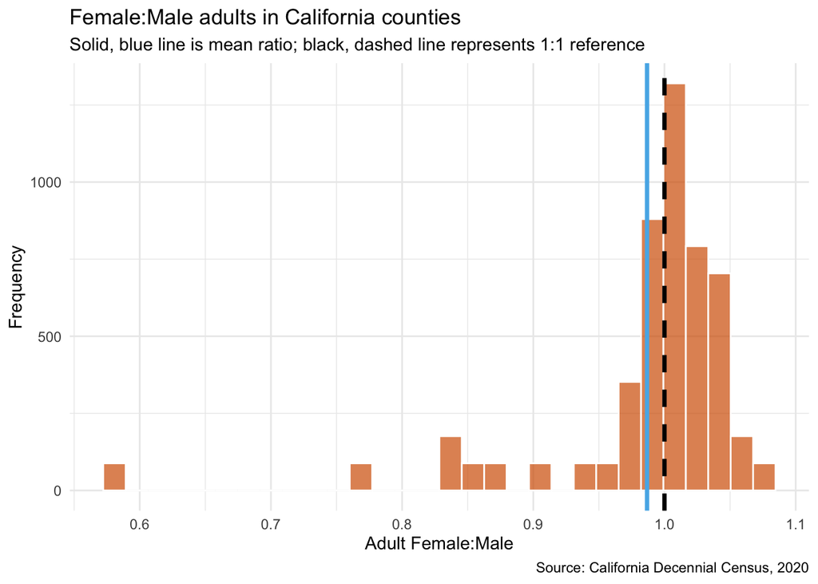

#### Question 22 [1 point]:

Calculate the correlation of `femaleMaleRatio` and the `deathsInjuriesProportion`, making sure to be careful to drop or exclude any NAs before making your calculation.

```r
## Calculate the correlation between the female:male ratio
## and the proportion of deaths due to accidents/injuries

injDeaths %>%
  select(femaleMaleRatio, deathsInjuriesProportion) %>%
  na.omit() %>%
  summarise(
    correlation = cor(femaleMaleRatio,
                      deathsInjuriesProportion)
  )
```

```
##   correlation
## 1    0.279791
```

Do you think that this correlation coefficient indicates that you need to make a correction on your maps, or is it likely sufficient just to make the correction in your models? In other words, large correlation coefficients (in the absolute value sense) would indicate a need to correct the maps; smaller coefficients would indicate that it’s probably not a big deal for your visualizations provided to stakeholders.

> We found a positive correlation of 0.280 between the female-to-male population ratio and the proportion of deaths due to accident or injury. This suggests that there is some relationship between the sex composition of a county and injury-related mortality, but the relationship is relatively weak. If the sex ratio were a major driver of injury mortality, we would expect a much stronger correlation. Because the correlation is modest, we do not think it is necessary to mathematically adjust the maps for differences in county sex ratios. Doing so would likely add complexity without substantially changing the overall patterns shown in the visualizations. However, because biological sex appears to be associated with injury-related mortality, it would still be appropriate to include the female-to-male ratio as a control variable in future statistical models. This allows us to account for any underlying population differences while keeping the maps straightforward and easier for stakeholders to interpret.

#### Question 23 [1 point]:

Now, take a look at the scatter plot below with a best-fit line. Does the plot agree with the correlation coefficient (i.e., direction of slope) you obtained? Why or why not?

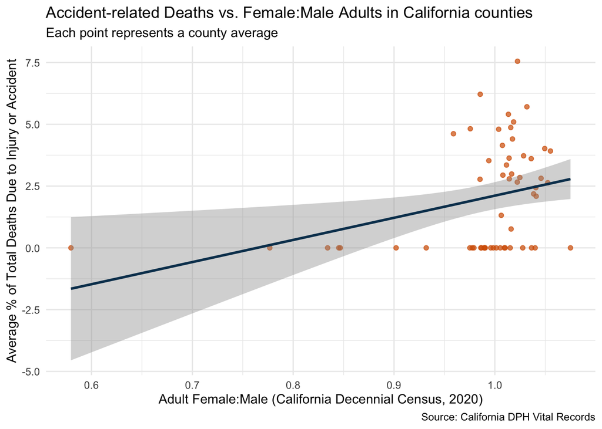

> A correlation of 0.280 indicates a weak positive relationship between the female-to-male population ratio and the proportion of deaths due to accident or injury. In the scatterplot, the fitted regression line has a slight upward slope, which is consistent with a positive correlation. This means that counties with relatively higher female-to-male ratios tend to have slightly higher proportions of accident- or injury-related deaths. However, the relationship appears fairly weak. The points are widely scattered around the trend line, and there is substantial variation in injury-related mortality even among counties with very similar female-to-male ratios. This suggests that while the sex ratio may have some influence, it is likely not a major driver of accident- and injury-related mortality on its own. Other factors, such as age distribution, population density, socioeconomic conditions, or geographic differences, are likely contributing more strongly to the variation observed across counties. This is why we concluded in Question 22 that it is probably sufficient to account for the female-to-male ratio in our statistical models rather than making additional corrections to the maps.

#### Question 24 [3 points]:

Originally, I was going to walk you through predictive modeling here as well - but given a need to abbreviate this project, instead I am going to ask you to simply construct **data science question** and **hypothesis** given the information you have here so far. Are there any variables you pulled from the Census that would be worth considering here as well?

Choose what kind of model you would do. Would you include spatial lags? Ideally, would you include temporal lags?

> Data Science Question: How did California’s COVID-19 stay-at-home orders affect the proportion of deaths due to accident and injury across counties, and were these effects influenced by county-level demographic characteristics and spatial relationships?

> Hypothesis: We hypothesize that the proportion of deaths due to accident and injury declined during the stay-at-home period because reduced travel and mobility likely lowered exposure to accidents. However, we also expect that the magnitude of this effect varied across counties due to differences in population characteristics, sex composition, age structure, and geographic location.

> Several Census-derived variables would be worth considering in the model, including the female-to-male population ratio, the female-to-male ratio among adults over age 65, the retiree ratio (population over age 65), and total county population size. These variables may help explain differences in injury-related mortality across counties and control for demographic variation.

> For modeling, we would likely use a random forest because the relationships appear to be non-linear and the method can accommodate complex interactions among predictors. We would also include a spatial lag variable because earlier analyses showed evidence of spatial dependence in mortality outcomes. Ideally, we would include temporal lag variables as well, since our previous results demonstrated that mortality exhibits strong temporal autocorrelation and seasonality. Including temporal lags would allow the model to capture recent trends and patterns that may not be fully explained by the month variable alone.

#### Question 25 [15 points]:

Now for the choose your own adventure portion of this assignment! Table 2 gives you a list of ICD-10 codes for the causes of death available in the dataset. You should be able to use the code in Section 5.1, with minimal adjustment, to explore your data.

Feel free to get creative! You are not required to continue stratifying by sex, unless you want to; in the Census data you pulled, you also have stratifications by **retirement age status** (over 65 years) or **double-stratified by both sex and retirement age**. You may also choose not to use any stratification if you wish.